# Breweries and Beer Case Study

adam tschannen

6/29/2017

With the data sets of Beers and Breweries we analyzed and found the number of breweries in each state, the median alcohol content and international bitterness unit for each state, which state has the maximum alcoholic beer, which state has the most bitter beer, a summary of the Alcohol by volume and the relationship between the bitterness of the beer and its alcoholic content?

```r
# read in csv files
brew<- read.csv(file="~/Downloads/Breweries_CaseStudy1.csv")
beer<- read.csv(file="~/Downloads/Beers_CaseStudy1.csv")
```

Below we can see the number of breweries in each state in in ascending order with Colorado having the most number of breweries with 47 and DC, North Dakota, South Dakota and West Virginia having the least number of breweries with 1.

```r
#part1
#count number of breweries in each state
#i plotted just for visualization
BrewPerState <- table(brew$State)
sort(BrewPerState)
```

```
##
##  DC  ND  SD  WV  AR  DE  MS  NV  AL  KS  NH  NJ  TN  HI  KY  NM  SC  UT
##   1   1   1   1   2   2   2   2   3   3   3   3   3   4   4   4   4   4
##  WY  IA  ID  LA  NE  RI  OK  AK  GA  MD  CT  ME  MO  MT  VT  AZ  MN  FL
##   4   5   5   5   5   5   6   7   7   7   8   9   9   9  10  11  12  15
##  OH  NY  VA  IL  NC  WI  IN  MA  WA  PA  TX  OR  MI  CA  CO
##  15  16  16  18  19  20  22  23  23  25  28  29  32  39  47
```

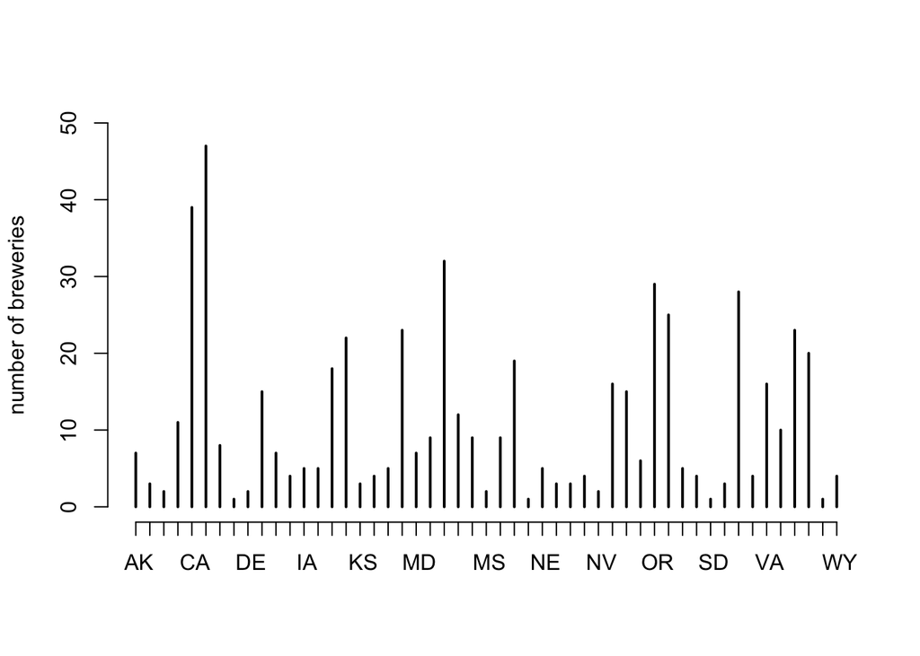

```r
plot(BrewPerState,ylab = "number of breweries", ylim=c(0,50))
```

Next, we merged the beer data with breweries data by brewery id. We did this so we would have all of our data on one sheet. To check that we executed this step correctly we printed first 6 observations and the last six observations to check the merged file.

The first step in merging was making sure that both data sets had the same variable name ‘Brewery_id’ so that we could merge them.

```r
names(brew)[1]<-"Brewery_id"
```

Next, we merged the data using our join function with library package plyr.

```r
library(plyr)
brewbeer <- join(x=brew, y=beer, by= 'Brewery_id')
```

Once we successfully merged the two data sets, I checked the structure of the data and labeled all of the missing variable names.

```r
str(brewbeer)
```

```
## 'data.frame':    2410 obs. of  10 variables:
##  $ Brewery_id: int  1 1 1 1 1 1 2 2 2 2 ...
##  $ Name      : Factor w/ 551 levels "10 Barrel Brewing Company",..: 355 355 355 355 355 355 12 12 12 12 ...
##  $ City      : Factor w/ 384 levels "Abingdon","Abita Springs",..: 228 228 228 228 228 228 200 200 200 200 ...
##  $ State     : Factor w/ 51 levels " AK"," AL"," AR",..: 24 24 24 24 24 24 18 18 18 18 ...
##  $ Name      : Factor w/ 2305 levels "#001 Golden Amber Lager",..: 802 1258 2185 1640 1926 1525 458 1218 43 71 ...
##  $ Beer_ID   : int  2692 2691 2690 2689 2688 2687 2686 2685 2684 2683 ...
##  $ ABV       : num  0.045 0.049 0.048 0.06 0.06 0.056 0.08 0.125 0.077 0.042 ...
##  $ IBU       : int  50 26 19 38 25 47 68 80 25 42 ...
##  $ Style     : Factor w/ 100 levels "","Abbey Single Ale",..: 16 77 48 83 22 57 12 46 77 18 ...
##  $ Ounces    : num  16 16 16 16 16 16 16 16 16 16 ...
```

```r
names(brewbeer)[3]<-"City"
names(brewbeer)[4]<-"State"
names(brewbeer)[2]<-"Brewering_Company"
```

finally, we print out the first and last 6 observations to check the merged file.

```r
head(brewbeer, n=6)
```

```
##   Brewery_id  Brewering_Company        City State          Name Beer_ID
## 1          1 NorthGate Brewing  Minneapolis    MN  Get Together    2692
## 2          1 NorthGate Brewing  Minneapolis    MN Maggie's Leap    2691
## 3          1 NorthGate Brewing  Minneapolis    MN    Wall's End    2690
## 4          1 NorthGate Brewing  Minneapolis    MN       Pumpion    2689
## 5          1 NorthGate Brewing  Minneapolis    MN    Stronghold    2688
## 6          1 NorthGate Brewing  Minneapolis    MN   Parapet ESB    2687
##     ABV IBU                               Style Ounces
## 1 0.045  50                        American IPA     16
## 2 0.049  26                  Milk / Sweet Stout     16
## 3 0.048  19                   English Brown Ale     16
## 4 0.060  38                         Pumpkin Ale     16
## 5 0.060  25                     American Porter     16
## 6 0.056  47 Extra Special / Strong Bitter (ESB)     16
```

```r
tail(brewbeer, n=6)
```

```
##      Brewery_id             Brewering_Company          City State
## 2405        556         Ukiah Brewing Company         Ukiah    CA
## 2406        557       Butternuts Beer and Ale Garrattsville    NY
## 2407        557       Butternuts Beer and Ale Garrattsville    NY
## 2408        557       Butternuts Beer and Ale Garrattsville    NY
## 2409        557       Butternuts Beer and Ale Garrattsville    NY
## 2410        558 Sleeping Lady Brewing Company     Anchorage    AK
##                           Name Beer_ID   ABV IBU                   Style
## 2405             Pilsner Ukiah      98 0.055  NA         German Pilsener
## 2406  Heinnieweisse Weissebier      52 0.049  NA              Hefeweizen
## 2407           Snapperhead IPA      51 0.068  NA            American IPA
## 2408         Moo Thunder Stout      50 0.049  NA      Milk / Sweet Stout
## 2409         Porkslap Pale Ale      49 0.043  NA American Pale Ale (APA)
## 2410 Urban Wilderness Pale Ale      30 0.049  NA        English Pale Ale
##      Ounces
## 2405     12
## 2406     12
## 2407     12
## 2408     12
## 2409     12
## 2410     12
```

Now, to see how many missing variables are in our data, we report the number of NA’s in each column.

```r
sapply(brewbeer, function(x) sum(is.na(x)))
```

```
##        Brewery_id Brewering_Company              City             State
##                 0                 0                 0                 0
##              Name           Beer_ID               ABV               IBU
##                 0                 0                62              1005
##             Style            Ounces
##                 0                 0
```

What we found is that there were 62 missing values in ABV and 1005 missing values in IBU.

Next, we found the median alcohol content and international bitterness unit for each state.

```r
library(doBy)
MedABVperState<-summaryBy(ABV ~ State, data = brewbeer, FUN = median, na.rm = TRUE)
MedIBUperState<-summaryBy(IBU ~ State, data = brewbeer, FUN = median, na.rm = TRUE)
range(MedABVperState$ABV.median)
```

```
## [1] 0.0400 0.0625
```

```r
range(MedIBUperState$IBU.median,na.rm=TRUE)
```

```
## [1] 19 61
```

```r
library(ggplot2)
MedABVperStatePlot<-ggplot(brewbeer, aes(x=factor(State), y=ABV)) + stat_summary(fun.y="median", geom="bar", na.rm = TRUE)
MedIBUperStatePlot<-ggplot(brewbeer, aes(x=factor(State), y=IBU)) + stat_summary(fun.y="median", geom="bar", na.rm =TRUE)
```

We found CO has the maximum alcoholic beer and OR has the most bitter beer.

```r
StateWMaxABV<-brewbeer[which.max(brewbeer$ABV),]
StateWMaxIBU<-brewbeer[which.max(brewbeer$IBU),]
```

Then to find a statistical summary for ABV (Alcohol by volume) variable we found the below stats.

```r
summary(brewbeer$ABV)
```

```
##    Min. 1st Qu.  Median    Mean 3rd Qu.    Max.    NA's
## 0.00100 0.05000 0.05600 0.05977 0.06700 0.12800      62
```

To find the relationship between the bitterness of the beer and its alcoholic content we made a scatter plot and checked its correlation .

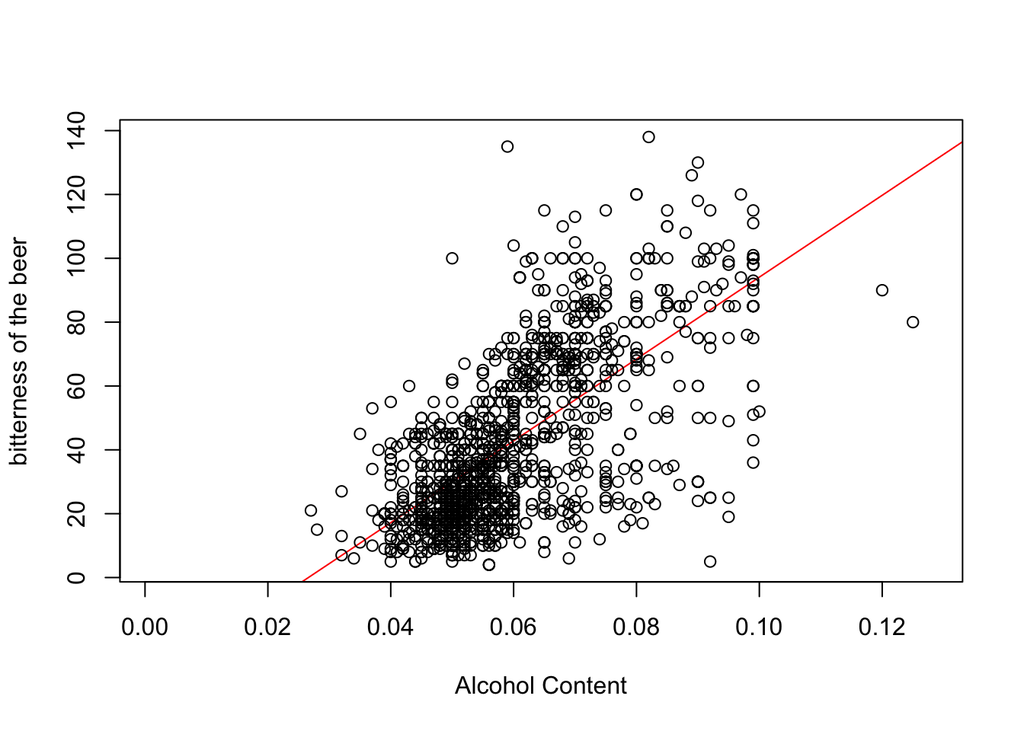

```r
plot<-plot(brewbeer$ABV, brewbeer$IBU,xlab = "Alcohol Content", ylab = "bitterness of the beer",abline(lm(brewbeer$IBU ~brewbeer$ABV), col="red"))
```

```r
#check for correlation
alcbitcor<-cor(brewbeer$ABV, brewbeer$IBU,use = "pairwise.complete.obs", method = "pearson")
alcbitcortest<-cor.test(brewbeer$ABV, brewbeer$IBU,use = "pairwise.complete.obs", method = "pearson")
```